# Week 5 - Dimensionality reduction techniques

```r
date()
```

```
## [1] "Thu Dec  2 10:11:55 2021"
```

## Introduction

This week, we are analyzing and modeling a dataset that describes various aspect of human development and gender inequalities stratified by countries. Data description is found [here](http://hdr.undp.org/en/content/human-development-index-hdi) and [here](http://hdr.undp.org/sites/default/files/hdr2015_technical_notes.pdf).

## Dataset

Begin by loading the analysis data. Let’s use the “official” csv-file; an R script to produce the wrangled data is in the [repo](https://github.com/kuuravar/IODS-project).

```r
rm(list=ls())

# read in the data, convert strings to factors
human <- read.csv("http://s3.amazonaws.com/assets.datacamp.com/production/course_2218/datasets/human2.txt",
                  header = TRUE, sep = ",", stringsAsFactors = TRUE)

dim(human)
```

```
## [1] 155   8
```

```r
summary(human)
```

```
##     Edu2.FM          Labo.FM          Edu.Exp         Life.Exp
##  Min.   :0.1717   Min.   :0.1857   Min.   : 5.40   Min.   :49.00
##  1st Qu.:0.7264   1st Qu.:0.5984   1st Qu.:11.25   1st Qu.:66.30
##  Median :0.9375   Median :0.7535   Median :13.50   Median :74.20
##  Mean   :0.8529   Mean   :0.7074   Mean   :13.18   Mean   :71.65
##  3rd Qu.:0.9968   3rd Qu.:0.8535   3rd Qu.:15.20   3rd Qu.:77.25
##  Max.   :1.4967   Max.   :1.0380   Max.   :20.20   Max.   :83.50
##       GNI            Mat.Mor         Ado.Birth         Parli.F
##  Min.   :   581   Min.   :   1.0   Min.   :  0.60   Min.   : 0.00
##  1st Qu.:  4198   1st Qu.:  11.5   1st Qu.: 12.65   1st Qu.:12.40
##  Median : 12040   Median :  49.0   Median : 33.60   Median :19.30
##  Mean   : 17628   Mean   : 149.1   Mean   : 47.16   Mean   :20.91
##  3rd Qu.: 24512   3rd Qu.: 190.0   3rd Qu.: 71.95   3rd Qu.:27.95
##  Max.   :123124   Max.   :1100.0   Max.   :204.80   Max.   :57.50
```

`Life.Exp` spans the range [49, 83.50], `GNI` [581, 123124], maternal mortality ratio (per 100000) [1.0, 1100] and adolescent birth rate (per 100000) [0.60, 204.80].

Plot the scatterplot and correlations between the variables.

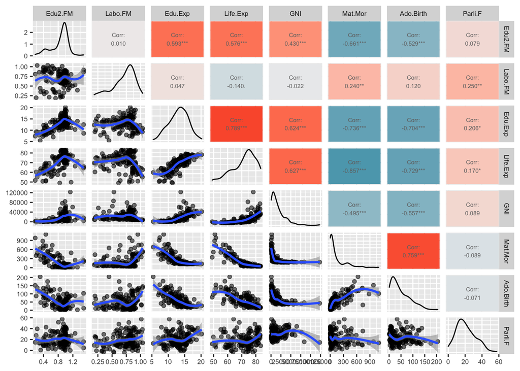

```r
library(GGally)
library(ggplot2)

lower <- function(data, mapping, method="loess", ...){
      p <- ggplot(data = data, mapping = mapping) +
      geom_point() +
      geom_smooth(method=method, ...)
      p
}

p <- ggpairs(human, mapping = aes(alpha = 0.3),
             lower = list(continuous = lower),
             upper = list(continuous = wrap("cor", size = 2))) +
      theme(text = element_text(size = 8))

# Add color to correlations
# stackoverflow.com/questions/45873483/

# correlations matrix plot
p.corr <- ggcorr(human, label = TRUE, label_round = 3,
                 palette = "RdBu")

# get colors
g2 <- ggplotGrob(p.corr)
colors <- g2$grobs[[6]]$children[[3]]$gp$fill

# Change background color to tiles in the upper triangular matrix of plots
idx <- 1
for (k1 in 1:(ncol(human) - 1)) {
  for (k2 in (k1 + 1):ncol(human)) {
    plt <- getPlot(p, k1, k2) +
     theme(panel.background = element_rect(fill = colors[idx], color="white"),
           panel.grid.major = element_line(color = colors[idx]))
    p <- putPlot(p, plt, k1, k2)
    idx <- idx + 1
  }
}

p
```

There are many significant strong correlations. Eg. `Life.Exp` correlates positively with `Edu.Exp`, and `Mat.Mor` correlates positively with `Ado.Birth`. `Life.Exp`, `Edu.Exp` correlate negatively with `Mat.Mor`. `Life.Exp` and `Ado.Birth` correlate negatively as well.

Let’s examine the correlations with corrplot also to see better the groups of positive and negative correlations. Only `Labo.FM` and `Parli.F` do not correlate strongly with anything.

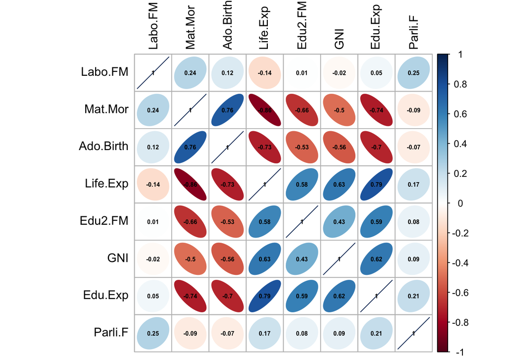

```r
library(corrplot)

cor.matrix <- cor(human)

rownames(cor.matrix) <- colnames(cor.matrix)

corrplot(as.matrix(cor.matrix), method = "ellipse",
         order = "AOE", number.cex = 0.5,  # Use some nice ordering
         tl.cex = 1, tl.col = "black", addCoef.col = 'black')
```

Then plot histograms to assess the distributions.

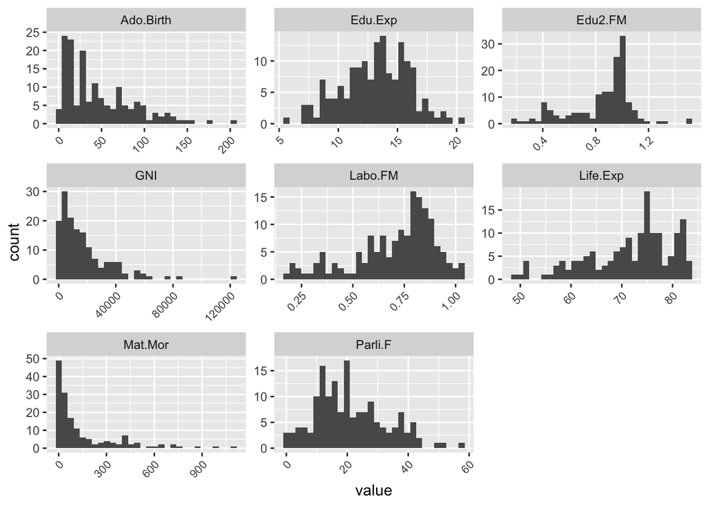

```r
library(tidyverse)

gather(human) %>% ggplot(aes(value)) +
  facet_wrap("key", scales = "free") +
  geom_histogram() + theme(axis.text.x = element_text(angle = 45, hjust = 1, size = 8))
```

`Edu.Exp` is close to normal distribution (passes Shapiro-Wilk normality test). `GNI`, `Mat.Mor` and `Ado.Birth` are right skewed, `Life.Exp` is left skewed.

## PCA

Perform PCA on non-standardized data first (follow code from course’s DataCamp)

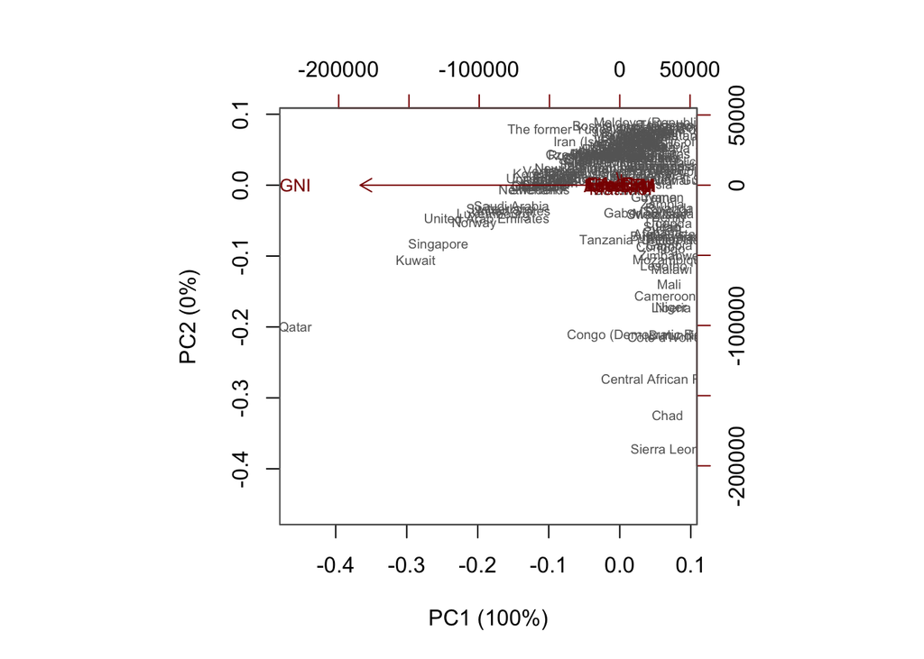

Figure 1. PCA on non-standardized data. GNI’s absolute variance is very large and it ends up explaining nearly all the absolute variance.

```r
human.pca <- prcomp(human)  # SVD

s <- summary(human.pca)

# rounded percentages of variance captured by each PC
pca.pr <- round(100 * s$importance[2,], digits = 1)

# create object pc_lab to be used as axis labels
pc.lab <- paste0(names(pca.pr), " (", pca.pr, "%)")

# draw a biplot
biplot(human.pca, cex = c(0.6, 0.8), col = c("grey40", "darkred"),
       xlab = pc.lab[1], ylab = pc.lab[2])
```

Well, since the data is not standardized, GNI appears to capture virtually all variability in the data as it has the highest absolute variance by far. Qatar stands out along the first PC and is opposite of e.g. Chad in GNI.

```r
sort(sapply(human, var))
```

```
##      Labo.FM      Edu2.FM      Edu.Exp     Life.Exp      Parli.F    Ado.Birth
## 3.951293e-02 5.838970e-02 8.067024e+00 6.942328e+01 1.319683e+02 1.690201e+03
##      Mat.Mor          GNI
## 4.485483e+04 3.438745e+08
```

Let’s standardize and replot.

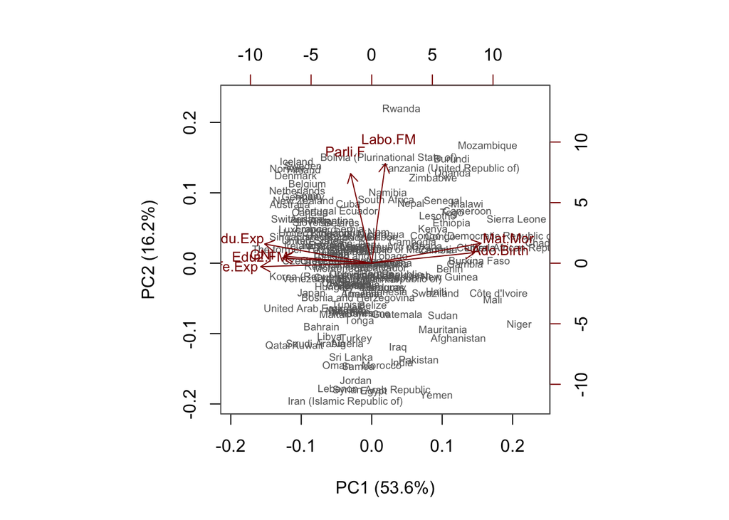

Figure 2. PCA on standardized data. Life expectancy, expected years of schooling and ratio of female to male populations with secondary education correlate with the first principal component and are of approximately same magnitude. They have an opposite effect to adolescent birth rate and maternal mortality. Ratio of labour force participation of females to males and percent of parliament representation for females are orthogonal to other variables and correlate with the second principal component.

```r
human.pca <- prcomp(human, scale = TRUE)

s <- summary(human.pca)

# rounded percentages of variance captured by each PC
pca.pr <- round(100 * s$importance[2,], digits = 1)

# create object pc_lab to be used as axis labels
pc.lab <- paste0(names(pca.pr), " (", pca.pr, "%)")

# draw a biplot
biplot(human.pca, cex = c(0.6, 0.8), col = c("grey40", "darkred"),
       xlab = pc.lab[1], ylab = pc.lab[2])
```

Now the two first principal components explain 69.8% of variation in the data, mainly due to PC1 (53.6%). `Life.Exp`, `Edu.Exp` and `Edu2.FM` all point along PC1 in the same direction, `Mot.Mor` and `Ado.Birth` point in the opposite direction, which is coherent with the correlation analysis. `Parli.F` and `Labo.FM` correlate with each other and PC2; as we calculated before, correlation is not very strong.

Third principal component explains around 9.6% of the variance and the following components less. 8 principal components are needed to fully explain the variance of the data.

```r
summary(human.pca)
```

```
## Importance of components:
##                           PC1    PC2     PC3     PC4     PC5     PC6     PC7
## Standard deviation     2.0708 1.1397 0.87505 0.77886 0.66196 0.53631 0.45900
## Proportion of Variance 0.5361 0.1624 0.09571 0.07583 0.05477 0.03595 0.02634
## Cumulative Proportion  0.5361 0.6984 0.79413 0.86996 0.92473 0.96069 0.98702
##                            PC8
## Standard deviation     0.32224
## Proportion of Variance 0.01298
## Cumulative Proportion  1.00000
```

## PCA interpretation

Based on the deductions above, we can conclude that PC1 mostly captures the variance in `Life.Exp`, `Edu.Exp` and `Edu2.FM`, as well as `Mot.Mor` and `Ado.Birth`. It explains 53.6% of the total variance in the standardized `human` data. `Mot.Mor` and `Ado.Birth` point very intuitively in the opposite direction to education, education ratio of females to males, and to life expectancy.

PC2 captures variance in `Parli.F` and `Labo.FM`, explaining 16.2% of the total variance in the data. These variables exhibit their effects in the same direction along PC2. Thus female parliament and labor representation are suggested to have similar effects.

All in all, the first two PCs are enough to approximately represent the data as the total variance explained is relatively good, 69.8%.

## Tea dataset

Load the tea dataset

```r
library(FactoMineR)

data(tea)

str(tea)
```

```
## 'data.frame':    300 obs. of  36 variables:
##  $ breakfast       : Factor w/ 2 levels "breakfast","Not.breakfast": 1 1 2 2 1 2 1 2 1 1 ...
##  $ tea.time        : Factor w/ 2 levels "Not.tea time",..: 1 1 2 1 1 1 2 2 2 1 ...
##  $ evening         : Factor w/ 2 levels "evening","Not.evening": 2 2 1 2 1 2 2 1 2 1 ...
##  $ lunch           : Factor w/ 2 levels "lunch","Not.lunch": 2 2 2 2 2 2 2 2 2 2 ...
##  $ dinner          : Factor w/ 2 levels "dinner","Not.dinner": 2 2 1 1 2 1 2 2 2 2 ...
##  $ always          : Factor w/ 2 levels "always","Not.always": 2 2 2 2 1 2 2 2 2 2 ...
##  $ home            : Factor w/ 2 levels "home","Not.home": 1 1 1 1 1 1 1 1 1 1 ...
##  $ work            : Factor w/ 2 levels "Not.work","work": 1 1 2 1 1 1 1 1 1 1 ...
##  $ tearoom         : Factor w/ 2 levels "Not.tearoom",..: 1 1 1 1 1 1 1 1 1 2 ...
##  $ friends         : Factor w/ 2 levels "friends","Not.friends": 2 2 1 2 2 2 1 2 2 2 ...
##  $ resto           : Factor w/ 2 levels "Not.resto","resto": 1 1 2 1 1 1 1 1 1 1 ...
##  $ pub             : Factor w/ 2 levels "Not.pub","pub": 1 1 1 1 1 1 1 1 1 1 ...
##  $ Tea             : Factor w/ 3 levels "black","Earl Grey",..: 1 1 2 2 2 2 2 1 2 1 ...
##  $ How             : Factor w/ 4 levels "alone","lemon",..: 1 3 1 1 1 1 1 3 3 1 ...
```

[output cut: 22 more lines]

```r
dim(tea)
```

```
## [1] 300  36
```

```r
table(sapply(tea, typeof))
```

```
##
## integer
##      36
```

The FactoMineR tea data has 300 rows and 36 columns, all of them except for `age` are factors encoded into integers. It is questionnaire data, from [documentation](https://cran.r-project.org/web/packages/FactoMineR/FactoMineR.pdf):

“We asked to 300 individuals how they drink tea (18 questions), what are their product’s perception (12 questions) and some personal details (4 questions).”

### Visualize the data

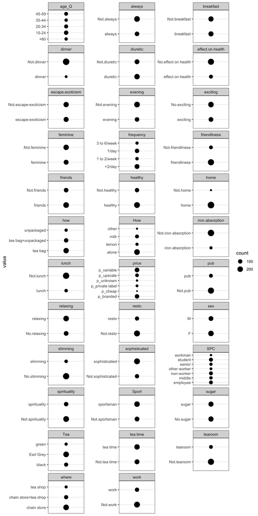

```r
# tea %>% select(-age) %>%
tea.cat <- tea %>% select(-age)

p <-
  tea %>%
    select(-age) %>%
    gather %>%
    group_by(value) %>%
    mutate(count = n()) %>%
    ggplot(aes(value)) + geom_point(y = .5, aes(size = count)) +
      facet_wrap("key", scales = "free", strip.position = "top", ncol = 3) +
      # facet_grid("key", scales = "free", space = "free") +
      theme(axis.text.x = element_text(angle = 45, vjust = 0.5, hjust=1),
            panel.spacing = unit(2, "lines")) +
      coord_flip() +
      theme_bw()

# https://stackoverflow.com/questions/52341385/
p
```

Plot age separately

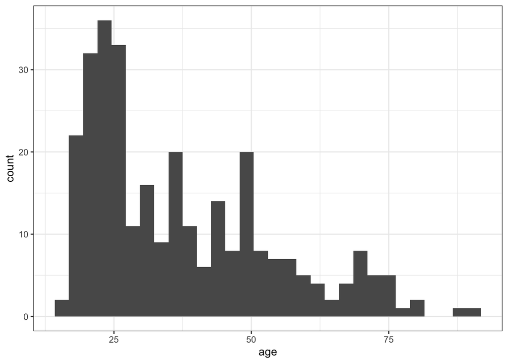

```r
ggplot(tea, aes(age)) + geom_histogram() + theme_bw()
```

### MCA

Perform multiple correspondence analysis (with indicator matrix) on the FactoMineR tea data.

```r
mca <- MCA(tea %>% select(-age), graph = FALSE)
summary(mca)
```

```
##
## Call:
## MCA(X = tea %>% select(-age), graph = FALSE)
##
##
## Eigenvalues
##                        Dim.1   Dim.2   Dim.3   Dim.4   Dim.5   Dim.6   Dim.7
## Variance               0.090   0.082   0.070   0.063   0.056   0.053   0.050
## % of var.              5.838   5.292   4.551   4.057   3.616   3.465   3.272
## Cumulative % of var.   5.838  11.130  15.681  19.738  23.354  26.819  30.091
##                        Dim.8   Dim.9  Dim.10  Dim.11  Dim.12  Dim.13  Dim.14
## Variance               0.048   0.047   0.044   0.041   0.040   0.039   0.037
## % of var.              3.090   3.053   2.834   2.643   2.623   2.531   2.388
## Cumulative % of var.  33.181  36.234  39.068  41.711  44.334  46.865  49.252
##                       Dim.15  Dim.16  Dim.17  Dim.18  Dim.19  Dim.20  Dim.21
## Variance               0.036   0.035   0.034   0.032   0.031   0.031   0.030
## % of var.              2.302   2.275   2.172   2.085   2.013   2.011   1.915
## Cumulative % of var.  51.554  53.829  56.000  58.086  60.099  62.110  64.025
##                       Dim.22  Dim.23  Dim.24  Dim.25  Dim.26  Dim.27  Dim.28
## Variance               0.028   0.027   0.026   0.025   0.025   0.024   0.024
## % of var.              1.847   1.740   1.686   1.638   1.609   1.571   1.524
## Cumulative % of var.  65.872  67.611  69.297  70.935  72.544  74.115  75.639
##                       Dim.29  Dim.30  Dim.31  Dim.32  Dim.33  Dim.34  Dim.35
## Variance               0.023   0.022   0.021   0.020   0.020   0.019   0.019
## % of var.              1.459   1.425   1.378   1.322   1.281   1.241   1.222
## Cumulative % of var.  77.099  78.523  79.901  81.223  82.504  83.745  84.967
##                       Dim.36  Dim.37  Dim.38  Dim.39  Dim.40  Dim.41  Dim.42
## Variance               0.018   0.017   0.017   0.016   0.015   0.015   0.014
## % of var.              1.152   1.092   1.072   1.019   0.993   0.950   0.924
## Cumulative % of var.  86.119  87.211  88.283  89.301  90.294  91.244  92.169
##                       Dim.43  Dim.44  Dim.45  Dim.46  Dim.47  Dim.48  Dim.49
## Variance               0.014   0.013   0.012   0.011   0.011   0.010   0.010
## % of var.              0.891   0.833   0.792   0.729   0.716   0.666   0.660
## Cumulative % of var.  93.060  93.893  94.684  95.414  96.130  96.796  97.456
##                       Dim.50  Dim.51  Dim.52  Dim.53  Dim.54
## Variance               0.009   0.009   0.008   0.007   0.006
## % of var.              0.605   0.584   0.519   0.447   0.390
## Cumulative % of var.  98.060  98.644  99.163  99.610 100.000
##
## Individuals (the 10 first)
```

[output cut: 44 more lines]

```
## dinner         0.796  1.805  0.048  3.777 |
## Not.dinner    -0.060  0.136  0.048 -3.777 |
##
## Categorical variables (eta2)
##                 Dim.1 Dim.2 Dim.3
## breakfast     | 0.031 0.000 0.011 |
## tea.time      | 0.240 0.000 0.003 |
## evening       | 0.040 0.087 0.062 |
## lunch         | 0.062 0.029 0.010 |
## dinner        | 0.092 0.000 0.048 |
## always        | 0.056 0.035 0.007 |
## home          | 0.016 0.002 0.030 |
## work          | 0.075 0.020 0.022 |
## tearoom       | 0.321 0.019 0.031 |
## friends       | 0.186 0.061 0.030 |
```

Eigenvalue output contains the variances and the respective percentage of variance explained by each dimension.

Individuals output shows the coordinates, contribution of the individual as percent, and the squared cosine which measures the degree of association between variable categories and a dimension [`[`1`]`)](http://www.sthda.com/english/articles/31-principal-component-methods-in-r-practical-guide/114-mca-multiple-correspondence-analysis-in-r-essentials/).

Categories are detailed similarly to individuals. The v.test measures if the category is significantly different from zero along a dimension (is abs(v.test) > 2, sign gives direction along the dimension). Categorical variables section shows squared correlation ratio to the dimensions.

Before going into interpretation, let’s - for pedagogical reasons - follow the [example](https://www.youtube.com/watch?v=reG8Y9ZgcaQ) of a FactoMineR developer and redo the MCA with age as a quantitative supplementary variable and a set of others as qualitative supplementary variables.

```r
mca <- MCA(tea, quanti.sup = 19, quali.sup = 20:36, graph = FALSE)  # 19 = "age"
summary(mca)
```

```
##
## Call:
## MCA(X = tea, quanti.sup = 19, quali.sup = 20:36, graph = FALSE)
##
##
## Eigenvalues
##                        Dim.1   Dim.2   Dim.3   Dim.4   Dim.5   Dim.6   Dim.7
## Variance               0.148   0.122   0.090   0.078   0.074   0.071   0.068
## % of var.              9.885   8.103   6.001   5.204   4.917   4.759   4.522
## Cumulative % of var.   9.885  17.988  23.989  29.192  34.109  38.868  43.390
##                        Dim.8   Dim.9  Dim.10  Dim.11  Dim.12  Dim.13  Dim.14
## Variance               0.065   0.062   0.059   0.057   0.054   0.052   0.049
## % of var.              4.355   4.123   3.902   3.805   3.628   3.462   3.250
## Cumulative % of var.  47.745  51.867  55.769  59.574  63.202  66.664  69.914
##                       Dim.15  Dim.16  Dim.17  Dim.18  Dim.19  Dim.20  Dim.21
## Variance               0.048   0.047   0.046   0.040   0.038   0.037   0.036
## % of var.              3.221   3.127   3.037   2.683   2.541   2.438   2.378
## Cumulative % of var.  73.135  76.262  79.298  81.982  84.523  86.961  89.339
##                       Dim.22  Dim.23  Dim.24  Dim.25  Dim.26  Dim.27
## Variance               0.035   0.031   0.029   0.027   0.021   0.017
## % of var.              2.323   2.055   1.915   1.821   1.407   1.139
## Cumulative % of var.  91.662  93.717  95.633  97.454  98.861 100.000
##
## Individuals (the 10 first)
##                  Dim.1    ctr   cos2    Dim.2    ctr   cos2    Dim.3    ctr
## 1             | -0.541  0.658  0.143 | -0.149  0.061  0.011 | -0.306  0.347
## 2             | -0.361  0.293  0.133 | -0.078  0.017  0.006 | -0.633  1.483
## 3             |  0.073  0.012  0.003 | -0.169  0.079  0.018 |  0.246  0.224
## 4             | -0.572  0.735  0.235 |  0.018  0.001  0.000 |  0.203  0.153
## 5             | -0.253  0.144  0.079 | -0.118  0.038  0.017 |  0.006  0.000
## 6             | -0.684  1.053  0.231 |  0.032  0.003  0.001 | -0.018  0.001
## 7             | -0.111  0.027  0.022 | -0.182  0.090  0.059 | -0.207  0.159
## 8             | -0.210  0.099  0.043 | -0.068  0.013  0.004 | -0.421  0.655
## 9             |  0.118  0.031  0.012 |  0.229  0.144  0.044 | -0.538  1.070
## 10            |  0.258  0.150  0.045 |  0.478  0.627  0.156 | -0.482  0.861
##                 cos2
## 1              0.046 |
## 2              0.409 |
## 3              0.038 |
## 4              0.030 |
```

[output cut: 69 more lines]

```
##                    Dim.1 Dim.2 Dim.3
## sex              | 0.033 0.017 0.003 |
## SPC              | 0.032 0.053 0.076 |
## Sport            | 0.001 0.000 0.002 |
## age_Q            | 0.008 0.077 0.146 |
## frequency        | 0.094 0.006 0.064 |
## escape.exoticism | 0.000 0.007 0.000 |
## spirituality     | 0.005 0.000 0.016 |
## healthy          | 0.000 0.000 0.008 |
## diuretic         | 0.004 0.000 0.013 |
## friendliness     | 0.071 0.001 0.013 |
##
## Supplementary continuous variable
##                  Dim.1    Dim.2    Dim.3
## age           |  0.042 |  0.204 | -0.340 |
```

The output of summary contains now also supplementary categories, for which there are no contributions as they are not used to build the explanatory dimensions.

Plot first the quantitative supplementary `age` variable. It seems `age` does not correlate strongly with the first two dimensions.

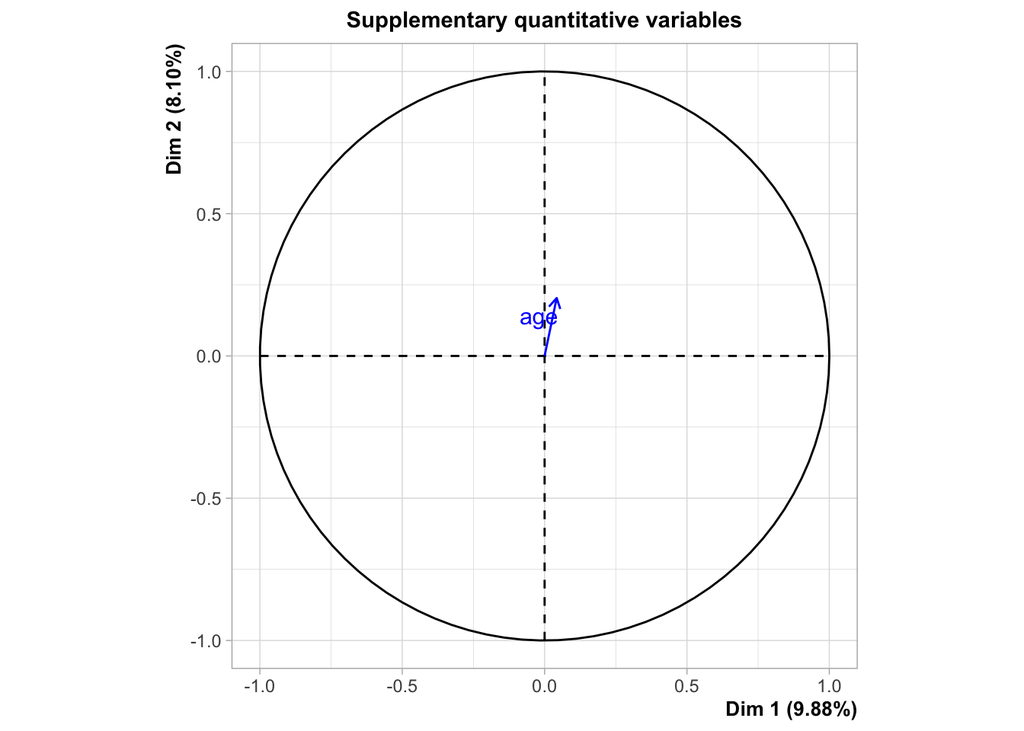

```r
plot.MCA(mca, choix = "quanti.sup")
```

Then plot variable graph for the correlation ratios. `where`, `tearoom` and `how` correlate with the first dimension more than other variables. Similarly `where`, `price` and `how` correlate with the second dimension more than the other variables. Active variables are in red, suppl. categorical variables in green, and suppl. continuous variable `age` in blue.

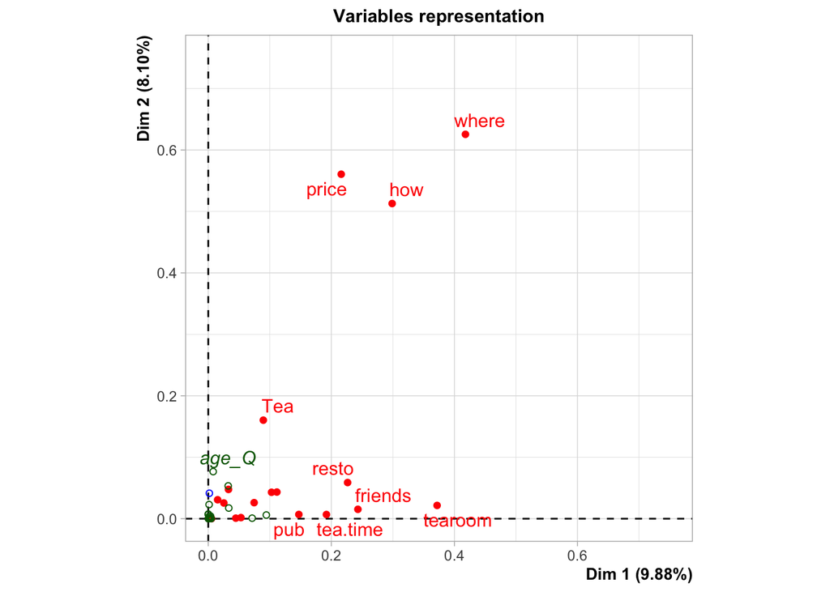

```r
plot.MCA(mca, choix = "var", xlim = c(0, 0.75), ylim = c(0, 0.75))
```

Then plot the graph for individuals and the category values. The plot is quite busy; it appears that the values `tea shop` (where), `unpackaged` (how) and `p_upscale` (price) are important for dimension 2. `other`(How [sic]) and `tearoom` (tearoom), `chain store+tea shop` (where) are important for dimension 1. Other data points are more clustered towards the middle.

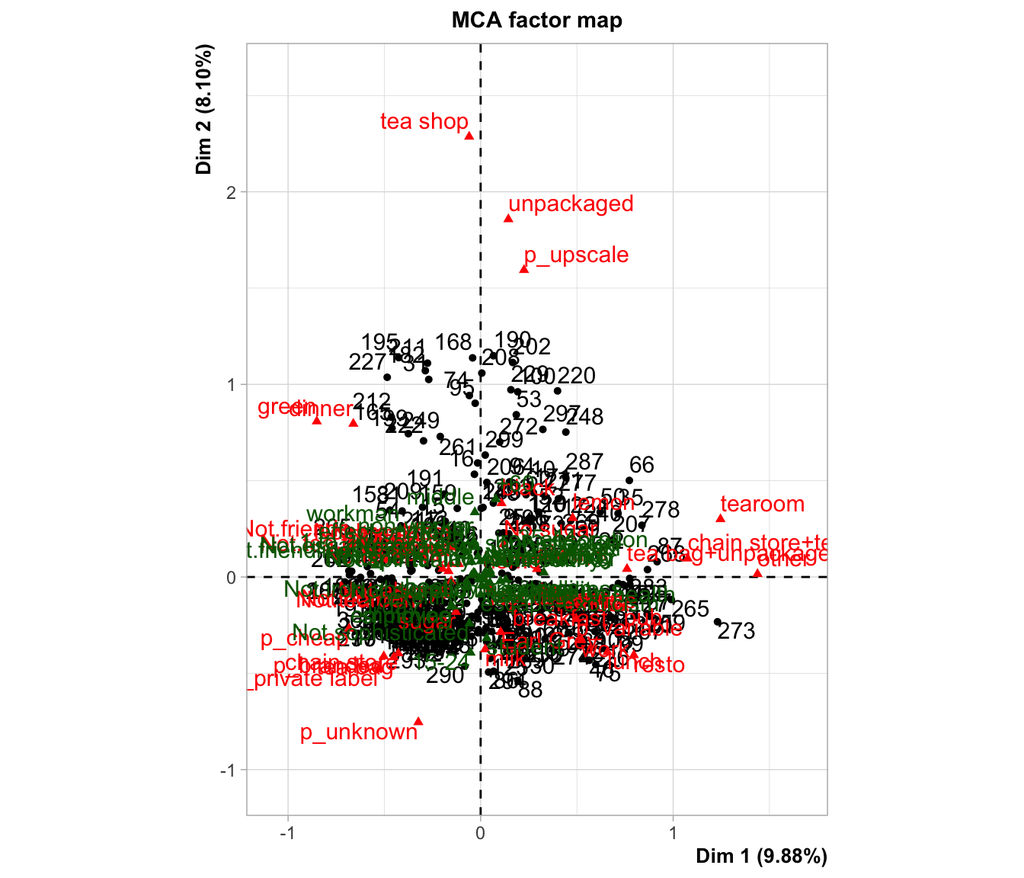

```r
plot.MCA(mca, choix = "ind")
```

For individuals, there appears to be a denser region in the third quadrant. Individuals contributing the most are on the periphery of the point cloud. It seems the individuals are separated nicely by where they get their tea from (`where`). This is not too suprising, as that variable was found to be important in the earlier plots.

Conclusions for the active categories are as before.

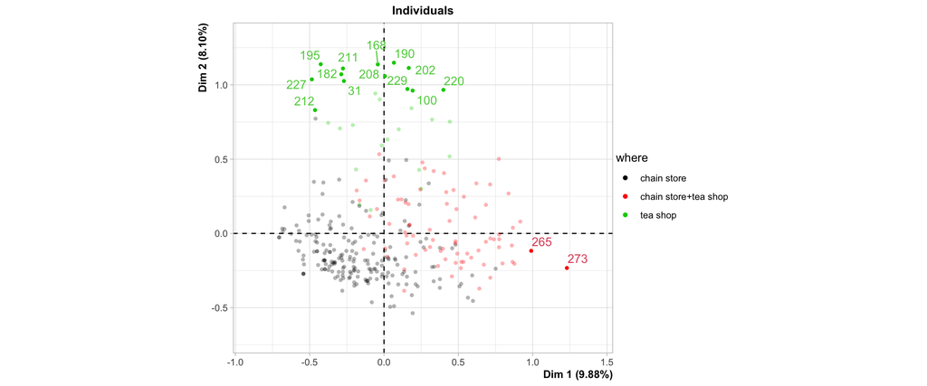

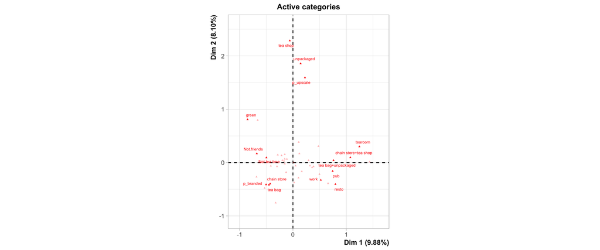

```r
op <- par(mfrow=c(1, 2),
          mar = c(4, 4, 2, 1),
          mgp = c(2, 1, 0))

plot(mca, invisible = c("var", "quali.sup", "quanti.sup"),
     title = "Individuals", select = "contrib 15", habillage = "where")
plot(mca, invisible = c("ind", "quali.sup", "quanti.sup"),
     title = "Active categories", autoLab = "yes", cex = 0.5,
     selectMod = "contrib 15")

par(op) # return original par
```